# Fisseha Berhane, PhD

#### Data Scientist

443-970-2353 fisseha@jhu.edu CV Resume

## Most Harmful Storms and Weather Events In The United States

### Summary

This report seeks to investigate storms and other weather events that cause the highest number of fatalities and injuries. Moreover, it shows which events have the greatest economic consequences. Understanding the impacts of different weather events on public health and the economy of the nation is essential to take necessary preparations and to mobilize resources in the right time. The data used for the analysis is drawn from the U.S. National Oceanic and Atmospheric Administration's [(NOAA)](http://www.noaa.gov/) storm database. The data for the analysis covers the period from 1950 to November 2011. The Analysis shows that Tornadoes are the most harmful weather events with respect to public health. Moreover, the analysis reveals that while floods result in the most harmful property damages, droughts cause the the most severe crop failures

### Data Processing

First and foremost, let's clear the workspace and load required libraries.

```r
rm(list=ls())    # clear workspace

   library(plyr)

   library(ggplot2)
   library(gridExtra)
```

Then, let's load the dataset and understand its contents. The data used for the analysis is drawn from the U.S. National Oceanic and Atmospheric Administration's [(NOAA)](http://www.noaa.gov/) storm database. The data for the analysis covers the period from 1950 to November 2011. The data can be downloaded from this [link](https://d396qusza40orc.cloudfront.net/repdata%2Fdata%2FStormData.csv.bz2).

```r
storm <- tempfile()

download.file("http://d396qusza40orc.cloudfront.net/repdata%2Fdata%2FStormData.csv.bz2", storm)

data <-read.csv(storm)

unlink(storm)

 names(data)   # To see the different variables of the dataset
```

1. "STATE__"

2. "BGN_DATE"

3. "BGN_TIME"

4. "TIME_ZONE"

5. "COUNTY"

6. "COUNTYNAME"

7. "STATE"

8. "EVTYPE"

9. "BGN_RANGE"

10. "BGN_AZI"

11. "BGN_LOCATI"

12. "END_DATE"

13. "END_TIME"

14. "COUNTY_END"

15. "COUNTYENDN"

16. "END_RANGE"

17. "END_AZI"

18. "END_LOCATI"

19. "LENGTH"

20. "WIDTH"

21. "F"

22. "MAG"

23. "FATALITIES"

24. "INJURIES"

25. "PROPDMG"

26. "PROPDMGEXP"

27. "CROPDMG"

28. "CROPDMGEXP"

29. "WFO"

30. "STATEOFFIC"

31. "ZONENAMES"

32. "LATITUDE"

33. "LONGITUDE"

34. "LATITUDE_E"

35. "LONGITUDE_"

36. "REMARKS"

37. "REFNUM"

So, from the list of variables, for our analysis we need event type, fatalities, property and crop damage, and property and crop damage exponent. Let's extract the variables of interest for further analysis.

```r
data2<-data[,c("EVTYPE", "FATALITIES", "INJURIES",
            "PROPDMG","PROPDMGEXP","CROPDMG","CROPDMGEXP")]

summary(data2)
```

```
               EVTYPE         FATALITIES          INJURIES
 HAIL             :288661   Min.   :  0.0000   Min.   :   0.0000
 TSTM WIND        :219940   1st Qu.:  0.0000   1st Qu.:   0.0000
 THUNDERSTORM WIND: 82563   Median :  0.0000   Median :   0.0000
 TORNADO          : 60652   Mean   :  0.0168   Mean   :   0.1557
 FLASH FLOOD      : 54277   3rd Qu.:  0.0000   3rd Qu.:   0.0000
 FLOOD            : 25326   Max.   :583.0000   Max.   :1700.0000
 (Other)          :170878
    PROPDMG          PROPDMGEXP        CROPDMG          CROPDMGEXP
 Min.   :   0.00          :465934   Min.   :  0.000          :618413
 1st Qu.:   0.00   K      :424665   1st Qu.:  0.000   K      :281832
 Median :   0.00   M      : 11330   Median :  0.000   M      :  1994
 Mean   :  12.06   0      :   216   Mean   :  1.527   k      :    21
 3rd Qu.:   0.50   B      :    40   3rd Qu.:  0.000   0      :    19
 Max.   :5000.00   5      :    28   Max.   :990.000   B      :     9
                   (Other):    84                     (Other):     9
```

```r
str(data2)
```

```
'data.frame':	902297 obs. of  7 variables:
 $ EVTYPE    : Factor w/ 985 levels "   HIGH SURF ADVISORY",..: 834 834 834 834 834 834 834 834 834 834 ...
 $ FATALITIES: num  0 0 0 0 0 0 0 0 1 0 ...
 $ INJURIES  : num  15 0 2 2 2 6 1 0 14 0 ...
 $ PROPDMG   : num  25 2.5 25 2.5 2.5 2.5 2.5 2.5 25 25 ...
 $ PROPDMGEXP: Factor w/ 19 levels "","-","?","+",..: 17 17 17 17 17 17 17 17 17 17 ...
 $ CROPDMG   : num  0 0 0 0 0 0 0 0 0 0 ...
 $ CROPDMGEXP: Factor w/ 9 levels "","?","0","2",..: 1 1 1 1 1 1 1 1 1 1 ...
```

We see that there is no missing value, so no need of imputting missing values. Next, let's calculate deaths and injuries by event type to determine which storms and other weather events are most harmful to public health in the nation.

```r
fatalities<-aggregate(FATALITIES~EVTYPE,data2,sum)
injuries<-aggregate(INJURIES~EVTYPE,data2,sum)
```

Let's look at the top 7 storms with the highest number of injuries and fatalities.

```r
top_7_fatality<-arrange(fatalities, desc(fatalities$FATALITIES))[1:7,]
top_7_injury<-arrange(injuries, desc(injuries$INJURIES))[1:7,]
```

Next, let's similarly extract the seven storms and weather events that cause the most severe propery and crop damage. First, however, let's see the exponents of property damage(PROPDMGEXP) and crop damage(CROPDMGEXP) in the dataset so as to convert the given property and crop damage values to thier exact values by multiplying them by the exponent variable.

```r
unique(data2$PROPDMGEXP)
```

1. K

2. M

4. B

5. m

6. +

7. 0

8. 5

9. 6

10. ?

11. 4

12. 2

13. 3

14. h

15. 7

16. H

17. -

18. 1

19. 8

```r
unique(data2$CROPDMGEXP)
```

2. M

3. K

4. m

5. B

6. ?

7. 0

8. k

9. 2

```r
for (i in 1:length(data2$CROPDMGEXP)){

       if (data2$PROPDMGEXP[i]=='k' | data2$PROPDMGEXP[i]=="K")
       {data2$PROPDMG[i]=data2$PROPDMG[i]*10^3}

       if (data2$PROPDMGEXP[i]=='B')
       {data2$PROPDMG[i]=data2$PROPDMG[i]*10^9}

       if (data2$PROPDMGEXP[i]=='m' |data2$PROPDMGEXP[i]=='M')
       {data2$PROPDMG[i]=data2$PROPDMG[i]*10^6}

       if (data2$PROPDMGEXP[i]=='h' | data2$PROPDMGEXP[i]=='H')
       {data2$PROPDMG[i]=data2$PROPDMG[i]*10^2}

       if (is.numeric(data2$PROPDMGEXP[i]))
       {data2$PROPDMG[i]=data2$PROPDMG[i]*10^data2$PROPDMGEXP[i]}


       if (data2$CROPDMGEXP[i]=='k' | data2$CROPDMGEXP[i]=="K")
       {data2$CROPDMG[i]=data2$CROPDMG[i]*10^3}

       if (data2$CROPDMGEXP[i]=='B')
       {data2$CROPDMG[i]=data2$CROPDMG[i]*10^9}

       if (data2$CROPDMGEXP[i]=='m' |data2$CROPDMGEXP[i]=='M')
       {data2$CROPDMG[i]=data2$CROPDMG[i]*10^6}

       if (data2$CROPDMGEXP[i]=='h' | data2$CROPDMGEXP[i]=='H')
       {data2$CROPDMG[i]=data2$CROPDMG[i]*10^2}

       if (is.numeric(data2$CROPDMGEXP[i]))
       {data2$CROPDMG[i]=data2$CROPDMG[i]*10^data2$CROPDMGEXP[i]}


   }
```

Now, let's calculate property damage and crop damage by event type.

```r
prop_damage<-aggregate(PROPDMG~EVTYPE,data2,sum)
crop_damage<-aggregate(CROPDMG~EVTYPE,data2,sum)
```

Next, let's see the top seven most severe stroms with the highest property and crop damage values.

```r
top_7_property<-arrange(prop_damage, desc(prop_damage$PROPDMG))[1:7,]
top_7_crop<-arrange(crop_damage, desc(crop_damage$CROPDMG))[1:7,]
```

### Results

Now, let's see barplots of fatalities and enjuries, by event type, of the top seven stroms with the highest number of fatalities and injuries.

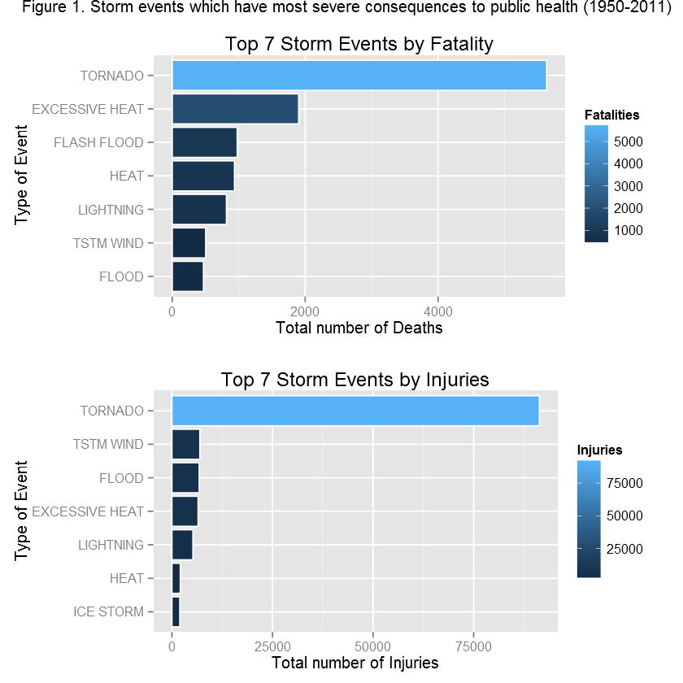

```r
#  Fatalities

colnames(top_7_fatality)<-c('EVTYPE', 'Fatalities')
colnames(top_7_injury)<-c('EVTYPE', 'Injuries')

f1<-  ggplot(top_7_fatality, aes(x=reorder(EVTYPE, Fatalities),
                             y=Fatalities,fill=Fatalities))+
       geom_bar(stat='identity',colour='white')+
       ggtitle('Top 7 Storm Events by Fatality')+
       xlab('Type of Event')+
       coord_flip()+
       ylab('Total number of Deaths')


#  Injuries

 f2<-  ggplot(top_7_injury, aes(x=reorder(EVTYPE, Injuries),
                            y=Injuries,fill=Injuries))+
       geom_bar(stat='identity',colour='white')+
       ggtitle('Top 7 Storm Events by Injuries')+
       xlab('Type of Event')+
       coord_flip()+
       ylab('Total number of Injuries')

grid.arrange(f1, f2, main="  Figure 1. Storm events which have most severe consequences to public health (1950-2011)")
```

Similarly, let's see barplots of the seven most severe storms with the highest propery and crop damage values.

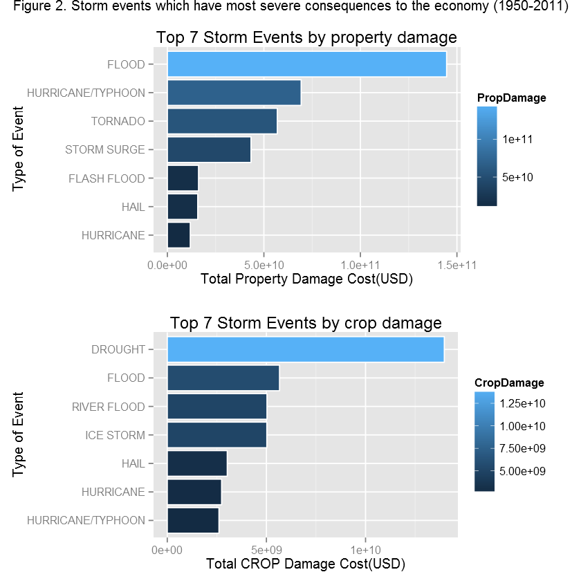

```r
#  Propery Damage

names(top_7_property)<-c('EVTYPE', 'PropDamage')
 f1<- ggplot(top_7_property, aes(x=reorder(EVTYPE, PropDamage),
                             y=PropDamage,fill=PropDamage))+
       geom_bar(stat='identity',colour='white')+
       ggtitle('Top 7 Storm Events by property damage')+
       xlab('Type of Event')+
      coord_flip()+
       ylab('Total Property Damage Cost(USD)')


#  Crop Damage

names(top_7_crop)<-c('EVTYPE', 'CropDamage')
 f2<-  ggplot(top_7_crop, aes(x=reorder(EVTYPE, CropDamage),
                            y=CropDamage,fill=CropDamage))+
       geom_bar(stat='identity',colour='white')+
       ggtitle('Top 7 Storm Events by crop damage')+
       xlab('Type of Event')+
        coord_flip()+
       ylab('Total CROP Damage Cost(USD)')

grid.arrange(f1, f2, main="Figure 2. Storm events which have most severe consequences to the economy (1950-2011)")
```

We see from the barplots that Tornadoes cause the highest problem to public health. While floods are associated with highest property damage, droughts result in the most severe crop failures.

### Summary

This short analysis is a project done for the Reproducible Research [course](https://class.coursera.org/repdata-014) offered by The Johns Hopkins Bloomberg School of Public Health, Department of [Biostatistics](http://www.jhsph.edu/departments/biostatistics/), on [Coursera](https://www.coursera.org/). The Analysis shows that Tornadoes are the most severe weather events interms of problems to public health. Moreover, the analysis reveals that while floods result in the most harmful property damages, droughts cause the the most severe crop failures.